# R Notebook

# LOAD DATASET

```r
library(readxl)
hsb2 <- read.csv("hsb2.csv")
View(hsb2)
```

# The datasets’ collection:

https://vincentarelbundock.github.io/Rdatasets/articles/data.html

# Der Datensatz für Pearson, t-Test (unabh.) und ANOVA:

https://vincentarelbundock.github.io/Rdatasets/csv/openintro/hsb2.csv https://vincentarelbundock.github.io/Rdatasets/doc/openintro/hsb2.html siehe auch Anhang für alle Variabeln

# Beschreibung

200 Beobachtungen wurden nach einem Zufallsprinzip im Rahmen einer Umfrage des US-Nationalen Zentrums für Bildungsstatistiken (National Center of Education Statistics) unter Oberstufenschülern (High School and Beyond) durchgeführt.

# Daten:

200 Beobachtungen 11 Variablen

# Pearson

Es wird ein Signifikanzniveau von alpha = 0.05 angenommen.

## Was soll untersucht werden?:

Es soll in dieser Untersuchung überprüft werden, ob ein Zusammenhang zwischen dem Score in einem Lese-Test und dem Score in einem Schreib-Test in der Stichprobe besteht.

## ANALYSE GLIEDERUNG:

0 Grundlegendes Konzept 1 Hypothese 2 Voraussetzungen 3 Deskriptive Statistik 4 Graphische Darstellung 5 Ergebnisse der Pearson Korrelations Analyse 6 Ergebniss der Bestimmtheitsmaß-Analyse 7 Aussage 8 Anhang

## Grundlegendes Konzept

Die Korrelation, auch bivariate Korrelation oder Produkt-Moment-Korrelation genannt, beschreibt den Zusammenhang von zwei intervallskalierten Merkmalen/Variablen einer Zufallsstichprobe. Eine Möglichkeit, die Stärke des Zusammenhangs zu bestimmen, ist die Berechnung des Korrelationskoeffizienten r nach Bravais und Pearson. Voraussetzung ist hierbei, dass es sich um einen linearen Zusammenhang zwischen den analysierten Merkmalen handelt. Zusätzlich wird hier ein ungerichteter Zusammenhang untersucht, d.h. die Variablen sind unabhängig voneinander und folglich werden keine kausalen Aussagen gemacht.

Achtung: Es kann dennoch ein Zusammenhang bestehen. Dieser ist dann allerdings nicht linear, sondern z.B. exponentiell. Um dies zu prüfen, müssen dann andere Tests angeschlossen werden.

Bei einer Korrelation wird der ungerichtete lineare Zusammenhang zweier Variablen untersucht. “Ungerichtet” bedeutet, dass nicht von einer abhängigen und einer unabhängigen Variable gesprochen wird. Es werden folglich keine kausalen Aussagen gemacht. Die Fragestellung einer Korrelation wird oft so verkürzt: “Gibt es einen Zusammenhang zwischen zwei Variablen?”

Der Korrelationskoeffizient r kann Werte zwischen -1 und +1 annehmen und ist unabhängig von der Maßeinheit. Ein Wert von -1 beschreibt eine perfekt negative Korrelation und ein Wert von +1 eine perfekt positive Korrelation. Bei r = 0 liegt kein linearer Zusammenhang zwischen den Variablen vor.

## Hypothese

H1: Es gibt einen Zusammenhang zwischen dem Lese-Score (read) und dem Schreib-Score (write). H0: Es gibt keinen Zusammenhang zwischen dem Lese-Score (read) und dem Schreib-Score (write).

## Voraussetzungen

Die Variablen sind mindestens intervallskaliert -> Ja, beide Varibalen sind metrisch und intervallskaliert. Die Variablen sind normalverteilt (n>30)-> siehe Histogramm Der untersuchte Zusammenhang zwischen den Variablen muss linear sein -> siehe Streudiagramm

## Deskrpitive Statistik

```r
head(hsb2)
```

|  | X | id | gender | race | ses | schtyp | prog | read | write | math | science | socst |
| --- | --- | --- | --- | --- | --- | --- | --- | --- | --- | --- | --- | --- |
| 1 | 1 | 70 | male | white | low | public | general | 57 | 52 | 41 | 47 | 57 |
| 2 | 2 | 121 | female | white | middle | public | vocational | 68 | 59 | 53 | 63 | 61 |
| 3 | 3 | 86 | male | white | high | public | general | 44 | 33 | 54 | 58 | 31 |
| 4 | 4 | 141 | male | white | high | public | vocational | 63 | 44 | 47 | 53 | 56 |
| 5 | 5 | 172 | male | white | middle | public | academic | 47 | 52 | 57 | 53 | 61 |
| 6 | 6 | 113 | male | white | middle | public | academic | 44 | 52 | 51 | 63 | 61 |

Deskripte Tabelle für einen groben Überblick

```r
library(psych)
describe(hsb2)
```

|  | vars | n | mean | sd | median | trimmed | mad | min | max | range | skew | kurtosis | se |
| --- | --- | --- | --- | --- | --- | --- | --- | --- | --- | --- | --- | --- | --- |
| X | 1 | 200 | 100.50 | 57.88 | 100.5 | 100.50 | 74.13 | 1 | 200 | 199 | 0.00 | -1.22 | 4.09 |
| id | 2 | 200 | 100.50 | 57.88 | 100.5 | 100.50 | 74.13 | 1 | 200 | 199 | 0.00 | -1.22 | 4.09 |
| gender* | 3 | 200 | 1.46 | 0.50 | 1.0 | 1.44 | 0.00 | 1 | 2 | 1 | 0.18 | -1.98 | 0.04 |
| race* | 4 | 200 | 3.47 | 0.98 | 4.0 | 3.71 | 0.00 | 1 | 4 | 3 | -1.68 | 1.35 | 0.07 |
| ses* | 5 | 200 | 2.19 | 0.86 | 2.0 | 2.23 | 1.48 | 1 | 3 | 2 | -0.36 | -1.55 | 0.06 |
| schtyp* | 6 | 200 | 1.84 | 0.37 | 2.0 | 1.92 | 0.00 | 1 | 2 | 1 | -1.84 | 1.40 | 0.03 |
| prog* | 7 | 200 | 1.73 | 0.84 | 1.0 | 1.66 | 0.00 | 1 | 3 | 2 | 0.55 | -1.37 | 0.06 |
| read | 8 | 200 | 52.23 | 10.25 | 50.0 | 52.03 | 10.38 | 28 | 76 | 48 | 0.19 | -0.66 | 0.72 |
| write | 9 | 200 | 52.77 | 9.48 | 54.0 | 53.36 | 11.86 | 31 | 67 | 36 | -0.47 | -0.78 | 0.67 |
| math | 10 | 200 | 52.65 | 9.37 | 52.0 | 52.23 | 10.38 | 33 | 75 | 42 | 0.28 | -0.69 | 0.66 |

[output cut: 2 more lines]

Der Datensatz umfasst 200 Beobachtungen. Es sind 11 Variablen im Datensatz aufgezeichnet (siehe Anhang). Es gibt keine fehlenden Daten im Datensatz.

read: Mittelwerte = 52.23, SD = 10.25, n = 200 write: Mittelwerte = 52.77, SD = 9.48, n = 200

## Graphische Darstellung

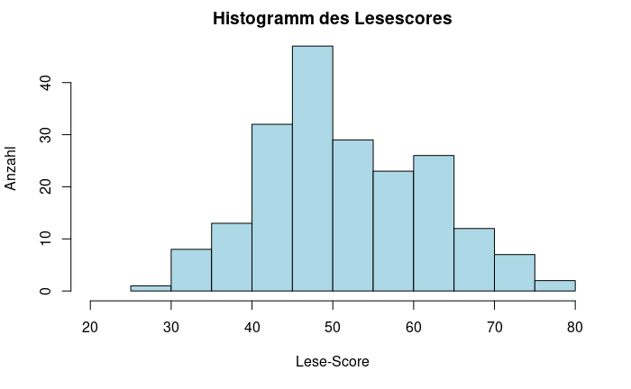

```r
hist(hsb2$read, main = "Histogramm des Lesescores", xlab = "Lese-Score", ylab ="Anzahl", col = "lightblue" ,breaks = 15, xlim = c(20,80))
```

Der Lese-Score ist annähernd normalverteilt. Es gibt mehr Beobachtungen in der Mitte der Skala, weniger an den Rändern.

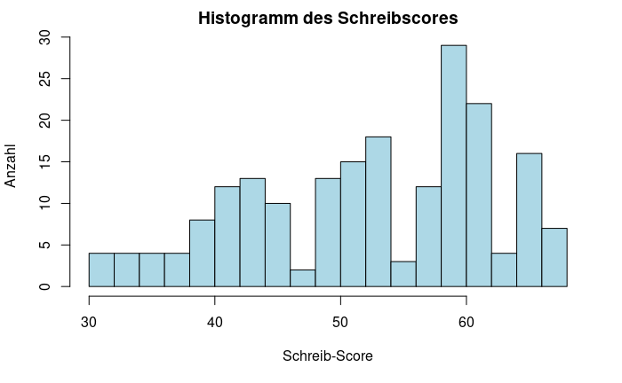

```r
hist(hsb2$write, main = "Histogramm des Schreibscores", xlab = "Schreib-Score", ylab ="Anzahl", col = "lightblue" ,breaks = 15)
```

Der Schreib-Score erscheint nicht normalverteilt. Aufgrund der großen Stichprobe (n>30, n = 200), ist dies jedoch vernachlässigbar (wenn auch nicht ideal) und immer noch für die Korrelationsanalyse geeignet.

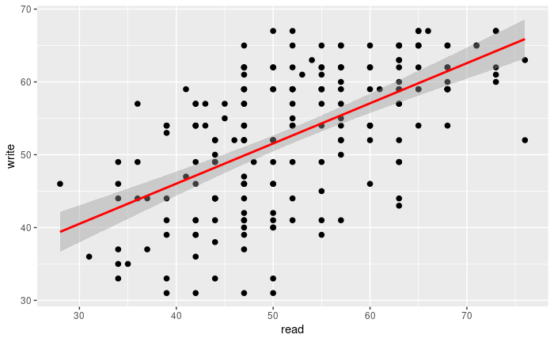

```r
library(ggplot2)
ggplot(hsb2, aes(x = read, y = write)) + geom_point(size = 2) + geom_smooth(method = "lm", col = "red")
```

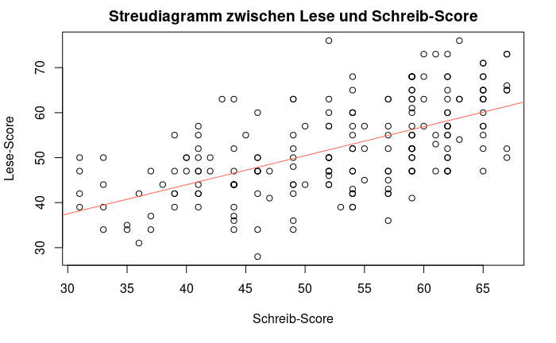

```r
plot(hsb2$read ~ hsb2$write, main = "Streudiagramm zwischen Lese und Schreib-Score", xlab = "Schreib-Score", ylab= "Lese-Score")
abline(lm(hsb2$read ~ hsb2$write, data = hsb2), col="tomato")
```

Die Abbildung zeigt eine tendenziell lineare Beziehung.

## Ergebnisse der Pearson-Korrelations Analyse

```r
test <- cor.test(hsb2$read, hsb2$write)
test
```

```
    Pearson's product-moment correlation

data:  hsb2$read and hsb2$write
t = 10.465, df = 198, p-value < 2.2e-16
alternative hypothesis: true correlation is not equal to 0
95 percent confidence interval:
 0.4993831 0.6792753
sample estimates:
      cor
0.5967765
```

Es wird ersichtlich, dass ein Zusammenhang vorliegt zwischen dem Lese- und Schreibscore (r = .597, p < 2.2e-16, n = 200). Da r einen positiven Wert aufweist, kann von einem starken (vergleiche Cohen (1992)) positiven linearen und signifikanten Zusammenhang zwischen Lese- und Schreibscore ausgegangen werden. Das bedeutet: Je höher der Lese-Score, desto höher war der Schreib-Score.

$$\begin{align}
\text{Schwacher Effekt: } 0.10 &< ||f|| < 0.30\\
\text{Schwacher bis mittlerer Effekt: } 0.30 = ||f|| \\
\text{Mittlerer Effekt: } 0.30 &< ||f|| < 0.50 \\
\text{Mittlerer bis starker Effekt: }0.50 &= ||f|| \\
\text{Starker Effekt: } 0.50 &< ||f||
\end{align}$$

## Bestimmheitsmaß

```r
rbestimmt <- test$estimate^2*100
sprintf("Das Bestimmtheitsmaß liegt bei %.2f Prozent.", rbestimmt)
```

```
[1] "Das Bestimmtheitsmaß liegt bei 35.61 Prozent."
```

Das Bestimmtheitsmaß gibt an, welcher Anteil der Varianz in beiden Variablen durch gemeinsame Varianzanteile determiniert wird. Für das vorliegende Beispiel beträgt der Anteil der gemeinsamen Varianz 35.61%.

# Aussage

Der Lese- und der Schreibscore korrelieren signifikant (r = .597, p < 2.2e-16, n = 200). Je höher der Lesescore eines Probanden, desto höher fällt auch sein Schreibscore aus. 35.61% der Streuung der gemeinsamen Varianz kann durch den Lese- und Schreib-Score erklärt werden. Es handelt sich nach Cohen (1992) um einen starken Effekt. H0 kann verworfen werden.

### Anhang:

VARIABELN UND BEDEUTUNG:

id Studenten ID

gender Geschlecht - männlich/weiblich

race Ethnie: Afroamerikaner, Asiaten, Hispanic, und Weiß.

ses Sozioökonomischer Status der Familien der Befragten: Niedrig, mittel, hoch.

schtyp Schultyp: Öffentlich und Privat (Schulen)

prog Programmtyp: Allgemein, akademisch , and Berufsausbildung.

read Standardisierte Lesescore.

write Standardisierte Schreibscore

math Standardisierte Mathescore

science Standardisierte Naturwissenschaftsscore

socst Standardisierte Sozialwissenschaftsscore